# Parameters for matrix population model with three-GC

Shohei Noda

2025-02-16

## 1 モデル

**3つの成長クラスターを含むステージ構造モデル**

## 2 データ

**インプットファイルの説明**

- “rawdata/WRFS_Sato_2010_fishdata.csv”：メス体サイズとと卵数のデータ
- “rawdata/WRFS_Data_241127.xlsx”：捕獲調査の生データ
- “output/rawdata_filtered.csv”：捕獲調査の生データに生活史情報を結合したデータ
- “output/k3_data.csv”：個体を成長パターンでクラスタリングしたデータ（成長クラスター）
- “output/phi_age0_2016cohort_GC3.csv”：2016年コホートにおける０歳10月までの生残率をCJSモデルで推定した結果
- “output/phi_age0_1_oct_2016cohort_GC3.csv”：０歳10月から1歳10月までの生残率をCJSモデルで推定した結果
- “output/phi_age1_2_oct_2016cohort_GC3.csv”：1歳10月から2歳10月までの生残率をCJSモデルで推定した結果
- “output/phi_age2_3_age2mature.csv”：2歳10月から3歳10月までの生残率をCJSモデルで推定した結果
- “output/predict_prob_age1maturity_GC3.csv”：GLMによる1際成熟確率の推定結果
- “output/predict_prob_age2maturity_GC3.csv”：GLMによる2際成熟確率の推定結果

## 3 パラメータの一覧

[output not shown]

## 4 *E(x)*: No. of eggs from female as a function of body length

```r
# read raw data
d0 <- read.csv("input_data/WRFS_Sato_2010_fishdata.csv")

d1 <- d0 %>%
  dplyr::select(id,timing,treatment,fl,w,egg,noegg) %>%
  filter(noegg > 0)

model <- glm(data = d1, noegg ~ fl, family = poisson(link="log"))
summary(model)
```

```
##
## Call:
## glm(formula = noegg ~ fl, family = poisson(link = "log"), data = d1)
##
## Coefficients:
##             Estimate Std. Error z value Pr(>|z|)
## (Intercept) 2.874038   0.219482  13.095  < 2e-16 ***
## fl          0.009250   0.001405   6.584 4.58e-11 ***
## ---
## Signif. codes:  0 '***' 0.001 '**' 0.01 '*' 0.05 '.' 0.1 ' ' 1
##
## (Dispersion parameter for poisson family taken to be 1)
##
##     Null deviance: 332.44  on 17  degrees of freedom
## Residual deviance: 289.21  on 16  degrees of freedom
## AIC: 400.99
##
## Number of Fisher Scoring iterations: 5
```

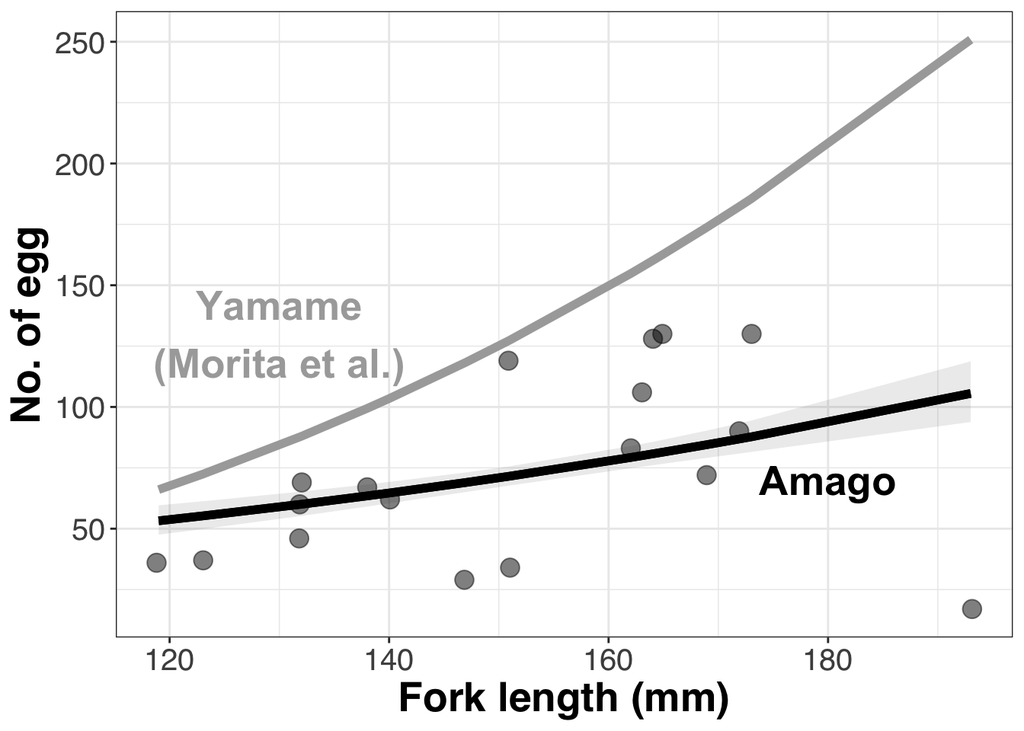

```r
# formula
## masou ishikawae
a1 = model$coefficients["(Intercept)"]
b1 = model$coefficients["fl"]

noegg_fl_1 <- function(x){
  y = exp(a1 + b1*x)
}

## masou masou
### The Ocean Ecology of Pacific Salmon and Trout, Chapter 6, Morita
a2 = -9.00
b2 = 2.76

noegg_fl_2 <- function(x){
  y = exp(a2 + b2*log(x))
}

# prediction
preds <- ggpredict(model, terms = c("fl[all]"), ci_level = 0.95)

preds <- tibble(
  fl = as.numeric(preds$x),
  predicted = preds$predicted,
  conf.low = preds$conf.low,
  conf.high = preds$conf.high,
  y1 = noegg_fl_1(preds$x),
  y2 = noegg_fl_2(preds$x)
)

# plot
g <-
  ggplot(NULL) +
  geom_jitter(data = d1, aes(x = fl, y = noegg),
              size = 4, height=0, width = 0.2, alpha=0.5) +
  # prediction
  geom_ribbon(data = preds, aes(x = fl, y = predicted,
                                ymin = conf.low, ymax = conf.high),
              alpha=0.1) +
  geom_line(data = preds, aes(x = fl, y = predicted), linewidth = 2) +

  # calculated value by two formulas
  geom_line(data = preds, aes(x = fl, y = y1), linewidth = 2, color = "black") +
  geom_line(data = preds, aes(x = fl, y = y2), linewidth = 2, color = "darkgray") +
  annotate("text", x=130, y=130, color = "darkgray", size = 7, fontface="bold",
           label="Yamame\n(Morita et al.)") +
  annotate("text", x=180, y=70, color = "black", size = 7, fontface="bold",
           label="Amago") +
  labs(x = "Fork length (mm)", y = "No. of egg")
g
```

## 5 *H*: Egg survival (egg to age-0 June)

sex ratio = 1:1

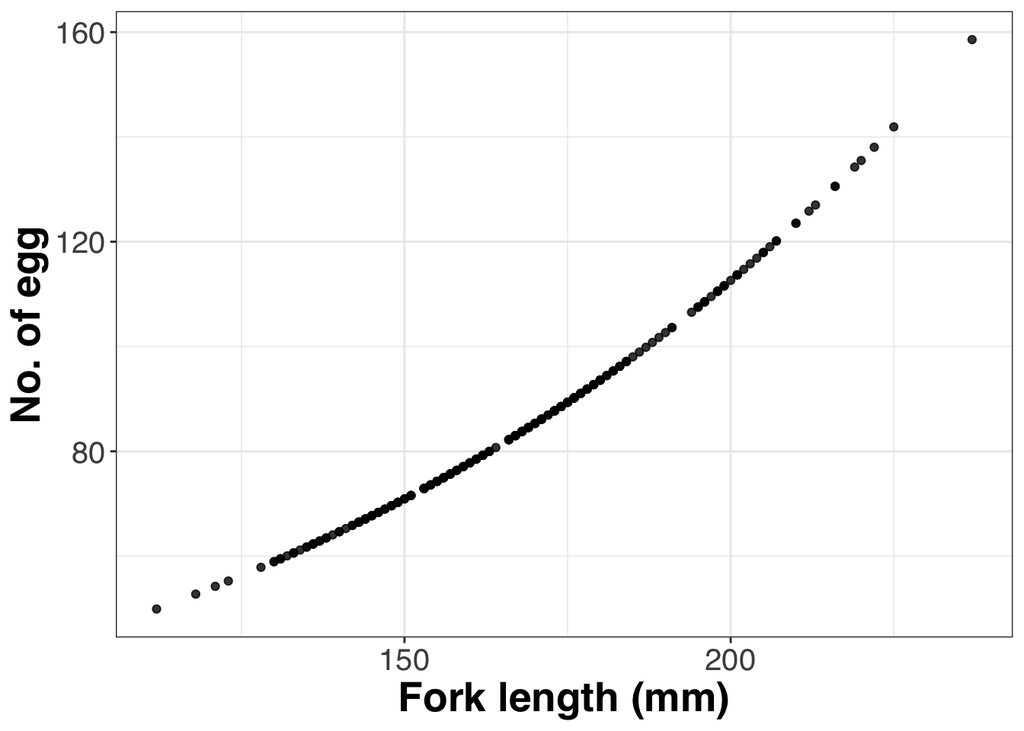

```r
# read raw data
data1 <- read.csv("./input_data/rawdata_filtered.csv")
data2 <- read.xlsx("input_data/WRFS_Data_241127.xlsx")
gc <- read.csv("./output/k3_data.csv")

# filtering
d1 <- data1 %>%
  left_join(gc, by="id") %>%
  filter(year == cohort,
         newsection == "C1" | newsection == "C2" | newsection == "C3"
         | newsection == "E1" | newsection == "E2" | newsection == "E3" | newsection == "Einter"
         | newsection == "L1" | newsection == "L2" | newsection == "L3") %>%
  distinct(id, year, .keep_all = TRUE)

# number of 0+ in June
age0jun <- count(d1, year, cohort)

# filtering
d2 <- data2 %>%
  # dplyr::select(id,year,month,fl,matureall,maturesex) %>%
  filter(newsection == "C1" | newsection == "C2" | newsection == "C3"
         | newsection == "E1" | newsection == "E2" | newsection == "E3" | newsection == "Einter"
         | newsection == "L1" | newsection == "L2" | newsection == "L3",
         matureall == "1",
         maturesex == "female") %>%
  filter(!grepl("\\?", fl)) %>%
  mutate(fl = as.numeric(fl))

# number of mature-female in Oct
mat_fem <- count(d2, year)

# Formula: relationship between fork length and egg number
d2 <- d2 %>%
  mutate(egg_num = noegg_fl_1(d2$fl))

# plot
g <- ggplot(d2,aes(x=fl, y=egg_num)) +
  geom_point(alpha=0.8) +
  xlab("Fork length (mm)") +
  ylab("No. of egg")
g
```

```r
# summarize egg number
sum_egg <- d2 %>%
  group_by(year) %>%
  summarise(sum = sum(egg_num)) %>%
  mutate(year = as.numeric(year) + 1) %>%
  left_join(age0jun, by = "year") %>%
  mutate(h0 = n / sum) %>%
  filter(year < 2024)

# calculate mean egg survival rate
h0 <- mean(sum_egg$h0)
h0
```

```
## [1] 0.08399448
```

## 6 *p, s, h*: juvenile survival rate (egg to age-0 Oct)

```r
treat_list <- c("control","early","late")

# read cjs data
data3 <- read.csv("./output/phi_age0_2016cohort_GC3.csv")

h_df <- tibble(
  estimate = c(),
  sd = c(),
  growth = c(),
  treatment = c()
)

for (treat in treat_list) {
  # p: proportion of growth cluster for 2016 cohort
  p_gc <- d1 %>%
    filter(cohort == 2016,
           treatment == treat) %>%
    count(ocluster_rename)
  p_gc <- p_gc$n / sum(p_gc$n)

  # s: survival rate June to Oct.
  # filtering
  d3 <- data3 %>%
    filter(treatment == treat)

  # calculate h1 - h4
  h1 = d3$mean[1]*h0*p_gc[1]
  h2 = d3$mean[2]*h0*p_gc[2]
  h3 = d3$mean[3]*h0*(1-p_gc[1]-p_gc[2])
  # make data frame
  h_df_sub <- tibble(
    growth = c(1,2,3),
    parameter = paste0("h",growth),
    estimate = c(h1,h2,h3),
    sd = c(0,0,0),
    treatment = c(treat,treat,treat),
  )
  h_df <- rbind(h_df,h_df_sub)
}

h_df
```

```
## # A tibble: 9 × 5
##   growth parameter estimate    sd treatment
##    <dbl> <chr>        <dbl> <dbl> <chr>
## 1      1 h1         0.00866     0 control
## 2      2 h2         0.0292      0 control
## 3      3 h3         0.0303      0 control
## 4      1 h1         0.0183      0 early
## 5      2 h2         0.0314      0 early
## 6      3 h3         0.0154      0 early
## 7      1 h1         0.00681     0 late
## 8      2 h2         0.0263      0 late
## 9      3 h3         0.0293      0 late
```

## 7 *f*: fertility (number of eggs)

data: 2915 and 2016 cohorts 2歳での体サイズは2015年コホートのみのデータを使用  
3歳では成長クラスターごとに体サイズ（卵数）を計算できないので、成長クラスター分けずに平均の体サイズで計算

```r
# read data
d0 <- read.csv("./input_data/rawdata_filtered.csv")
gc <- read.csv("./output/k3_data.csv")

d1 <- d0 %>%
  left_join(gc, by="id") %>%
  mutate(growth_cluster = case_when(ocluster_rename == 1 ~ '1',
                                    ocluster_rename == 2 ~ '2',
                                    ocluster_rename == 3 ~ '3',
                                    TRUE ~ "nd"),
         fl = as.numeric(fl),
         age = year - cohort) %>%
  filter(!grepl("\\?", fl),
         fl != "nd",
         growth_cluster != "nd",
         treatment == 'control' | treatment == 'early' | treatment == 'late',
         month == 9 | month == 10 | month == 11,
         matureall == 1,
         age != 0, age != 4,
         sex == "female" | sex == "female?")

# check data
count(d1, age, growth_cluster)
```

```
##   age growth_cluster  n
## 1   1              1 10
## 2   1              2 21
## 3   1              3  3
## 4   2              1  5
## 5   2              2 13
## 6   2              3  3
## 7   3              1  1
## 8   3              3  3
```

```r
# age-3
d2 <- d0 %>%
  left_join(gc, by="id") %>%
  mutate(fl = as.numeric(fl),
         age = year - cohort) %>%
  filter(!grepl("\\?", fl),
         fl != "nd",
         treatment == 'control' | treatment == 'early' | treatment == 'late',
         month == 9 | month == 10 | month == 11,
         matureall == 1,
         age != 0, age != 4,
         sex == "female" | sex == "female?")

# summarize fork length and egg number for growth cluster
# sex ratio = 1:1 in eggs
# eggs(female) = total eggs / 2
# age-1 and age-2
gc_egg1 <- d1 %>%
  filter(age == 1 | age == 2) %>%
  mutate(egg_num = noegg_fl_1(fl)/2) %>%
  group_by(age, growth_cluster) %>%
  summarise(mean = mean(egg_num),
            sd = sd(egg_num),
            n = n(),
            .groups = "drop") %>%
  mutate(id = paste0("f", as.character(age), as.character(growth_cluster)))
# age-3
gc_egg2 <- d2 %>%
  filter(age == 3) %>%
  mutate(egg_num = noegg_fl_1(fl)/2) %>%
  group_by(age) %>%
  summarise(mean = mean(egg_num),
            sd = sd(egg_num),
            n = n(),
            .groups = "drop") %>%
  mutate(id = paste0("f", as.character(age)))

# make data frame
f_df1 <- tibble(
  growth = gc_egg1$growth_cluster,
  parameter = gc_egg1$id,
  estimate = gc_egg1$mean,
  sd = gc_egg1$sd,
  treatment = "control"
)
f_df2 <- tibble(
  growth = "non",
  parameter = gc_egg2$id,
  estimate = gc_egg2$mean,
  sd = gc_egg2$sd,
  treatment = "control"
)
f_df <- rbind(f_df1,f_df2)
f_df
```

```
## # A tibble: 7 × 5
##   growth parameter estimate     sd treatment
##   <chr>  <chr>        <dbl>  <dbl> <chr>
## 1 1      f11           41.1  3.66  control
## 2 2      f12           34.9  2.94  control
## 3 3      f13           28.9  3.77  control
## 4 1      f21           64.3  8.94  control
## 5 2      f22           45.5  6.01  control
## 6 3      f23           33.3  0.472 control
## 7 non    f3            48.8 10.2   control
```

## 8 *u*: immature-survival (Oct to Oct)

```r
treat_list <- c("control","early","late")

# read data
d1<- read.csv("./output/phi_age0_1_oct_2016cohort_GC3.csv")
d2<- read.csv("./output/phi_age1_2_oct_2016cohort_GC3.csv")
d3<- read.csv("./output/phi_age2_3_age2mature.csv")

u_df <- tibble(
  growth = c(),
  parameter = c(),
  estimate = c(),
  sd = c(),
  treatment = c()
)

for (treat in treat_list) {
  # age 0 to 1
  phi_age01 <- d1 %>%
    filter(treatment == treat) %>%
    group_by(CL) %>%
    summarise(mean = mean,
              sd = sd,
              .groups = "drop") %>%
    mutate(growth = as.character(CL),
           id = paste0("u0", growth))
  # age 1 to 2
  phi_age12 <- d2 %>%
    filter(treatment == treat,
           age1_mature == 0) %>%
    group_by(CL) %>%
    summarise(mean = mean,
              sd = sd,
              .groups = "drop") %>%
    mutate(growth = as.character(CL),
           id = paste0("u1", growth))
  # age 2 to 3
  phi_age23 <- d3 %>%
    filter(age == 3,
           age2_maturity == 0) %>%
    group_by(age) %>%
    mutate(value = mean) %>%
    summarise(mean = mean(value),
              sd = sd(value),
              n = n(),
              .groups = "drop") %>%
    mutate(growth = "non",
           id = "u2")

  u_df_sub <- tibble(
    growth = c(phi_age01$growth, phi_age12$growth, phi_age23$growth),
    parameter = c(phi_age01$id, phi_age12$id, phi_age23$id),
    estimate = c(phi_age01$mean, phi_age12$mean, phi_age23$mean),
    sd = c(phi_age01$sd, phi_age12$sd, phi_age23$sd),
    treatment = treat
  )
  u_df <- rbind(u_df,u_df_sub)
}
u_df
```

```
## # A tibble: 19 × 5
##    growth parameter estimate     sd treatment
##    <chr>  <chr>        <dbl>  <dbl> <chr>
##  1 1      u01        0.453   0.231  control
##  2 2      u02        0.868   0.114  control
##  3 3      u03        0.737   0.0945 control
##  4 1      u11        0.00140 0.0348 control
##  5 2      u12        0.532   0.163  control
##  6 3      u13        0.377   0.136  control
##  7 non    u2         0.334   0.0503 control
##  8 1      u01        0.410   0.146  early
##  9 2      u02        0.645   0.113  early
## 10 3      u03        0.775   0.173  early
## 11 2      u12        0.635   0.224  early
## 12 3      u13        0.816   0.179  early
## 13 non    u2         0.334   0.0503 early
## 14 1      u01        0.816   0.212  late
## 15 2      u02        0.828   0.162  late
## 16 3      u03        0.604   0.128  late
## 17 2      u12        0.429   0.171  late
## 18 3      u13        0.589   0.138  late
## 19 non    u2         0.334   0.0503 late
```

## 9 *v*: mature-survival (Oct to Oct)

```r
treat_list <- c("control","early","late")

# read data
d2 <- read.csv("./output/phi_age1_2_oct_2016cohort_GC3.csv")
d3 <- read.csv("./output/phi_age2_3_age2mature.csv")

v_df <- tibble(
  parameter = c(),
  estimate = c(),
  sd = c(),
  treatment = c()
)

for (treat in treat_list) {
  # age 1 to 2
  phi_age12 <- d2 %>%
    filter(treatment == treat,
           age1_mature == 1) %>%
    group_by(CL) %>%
    summarise(mean = mean,
              sd = sd,
              .groups = "drop") %>%
    mutate(growth = as.character(CL),
           id = paste0("v1", growth))
  # age 2 to 3
  phi_age23 <- d3 %>%
    filter(age == 3,
           age2_maturity == 1) %>%
    group_by(age) %>%
    mutate(value = mean) %>%
    summarise(mean = mean(value),
              sd = sd(value),
              n = n(),
              .groups = "drop") %>%
    mutate(growth = "non",
           id = "v2")

  v_df_sub <- tibble(
    growth = c(phi_age12$growth, phi_age23$growth),
    parameter = c(phi_age12$id, phi_age23$id),
    estimate = c(phi_age12$mean, phi_age23$mean),
    sd = c(phi_age12$sd, phi_age23$sd),
    treatment = treat
  )
  v_df <- rbind(v_df,v_df_sub)
}
v_df
```

```
## # A tibble: 10 × 5
##    growth parameter estimate      sd treatment
##    <chr>  <chr>        <dbl>   <dbl> <chr>
##  1 1      v11       0.0451   0.159   control
##  2 2      v12       0.316    0.171   control
##  3 non    v2        0.104    0.0596  control
##  4 1      v11       0.000317 0.00656 early
##  5 2      v12       0.161    0.124   early
##  6 3      v13       0.00339  0.0329  early
##  7 non    v2        0.104    0.0596  early
##  8 1      v11       0.000370 0.00619 late
##  9 2      v12       0.0386   0.123   late
## 10 non    v2        0.104    0.0596  late
```

## 10 *m*: prob. of maturation

```r
treat_list <- c("control","early","late")

# age-1 maturity
## read data
d1 <- read.csv("./output/predict_prob_age1maturity_GC3.csv")

m_df <- tibble(
  growth = c(),
  parameter = c(),
  estimate = c(),
  sd = c(),
  treatment = c()
)

# control
dsub <- d1 %>%
  filter(treatment == "control")
m_df_sub <- tibble(
  growth = dsub$growth_cluster,
  parameter = paste0("m0",growth),
  estimate = dsub$predicted,
  sd = dsub$sd,
  treatment = "control"
)
m_df <- rbind(m_df,m_df_sub)
# early
dsub <- d1 %>%
  filter(treatment == "early")
m_df_sub <- tibble(
  growth = dsub$growth_cluster,
  parameter = paste0("m0",growth),
  estimate = dsub$predicted,
  sd = dsub$sd,
  treatment = "early"
)
m_df <- rbind(m_df,m_df_sub)
# late
dsub <- d1 %>%
  filter(treatment == "late")
m_df_sub <- tibble(
  growth = dsub$growth_cluster,
  parameter = paste0("m0",growth),
  estimate = dsub$predicted,
  sd = dsub$sd,
  treatment = "late"
)
m_df <- rbind(m_df,m_df_sub)

# age-2 maturity
## read data
d1 <- read.csv("./output/predict_prob_age2maturity_GC3.csv")

# control
dsub <- d1 %>%
  filter(treatment == "control")
m_df_sub <- tibble(
  growth = dsub$growth_cluster,
  parameter = paste0("m1",growth),
  estimate = dsub$predicted,
  sd = dsub$sd,
  treatment = "control"
)
m_df <- rbind(m_df,m_df_sub)
# early
dsub <- d1 %>%
  filter(treatment == "early")
m_df_sub <- tibble(
  growth = dsub$growth_cluster,
  parameter = paste0("m1",growth),
  estimate = dsub$predicted,
  sd = dsub$sd,
  treatment = "early"
)
m_df <- rbind(m_df,m_df_sub)
# late
dsub <- d1 %>%
  filter(treatment == "late")
m_df_sub <- tibble(
  growth = dsub$growth_cluster,
  parameter = paste0("m1",growth),
  estimate = dsub$predicted,
  sd = dsub$sd,
  treatment = "late"
)
m_df <- rbind(m_df,m_df_sub)

# age-3 maturity
## Age 3 maturation = 1.0

m_df_sub <- tibble(
  growth = "non",
  parameter = "m2",
  estimate = 1,
  sd = 0,
  treatment = c("control","early","late")
)
m_df <- rbind(m_df,m_df_sub)
m_df
```

```
## # A tibble: 21 × 5
##    growth parameter estimate    sd treatment
##    <chr>  <chr>        <dbl> <dbl> <chr>
##  1 1      m01         0.918  1.11  control
##  2 2      m02         0.326  0.450 control
##  3 3      m03         0.0584 0.600 control
##  4 1      m01         0.974  1.12  early
##  5 2      m02         0.623  0.445 early
##  6 3      m03         0.175  0.545 early
##  7 1      m01         0.907  1.09  late
##  8 2      m02         0.296  0.548 late
##  9 3      m03         0.0511 0.675 late
## 10 1      m11         0.966  1.17  control
## # ℹ 11 more rows
```

## 11 output: parameter list

```r
# h (hatching): 3
# f (fertility): 7
# u (juvenile to juvenile survival): 7
# v (adult to adult survival): 4
# m (maturation): 6

para <- rbind(h_df,f_df,u_df,v_df,m_df)

para_c <- para %>%
  filter(treatment == "control") %>%
  dplyr::select(parameter,estimate,sd) %>%
  rename(estimate_control = estimate,
         sd_control = sd)
para_e <- para %>%
  filter(treatment == "early") %>%
  dplyr::select(parameter,estimate,sd) %>%
  rename(estimate_early = estimate,
         sd_early = sd)
para_l<- para %>%
  filter(treatment == "late") %>%
  dplyr::select(parameter,estimate,sd) %>%
  rename(estimate_late = estimate,
         sd_late = sd)

# make new parameter data frame
para_list <- tibble(
  parameter = c(
    "h1","h2","h3",
    "f11","f12","f13","f21","f22","f23","f3",
    "u01","u02","u03","u11","u12","u13","u2",
    "v11","v12","v13","v2",
    "m01","m02","m03","m11","m12","m13","m2"
    )) %>%
  left_join(para_c, by = "parameter") %>%
  left_join(para_e, by = "parameter") %>%
  left_join(para_l, by = "parameter")

# NA to "-"
para_list2 <- para_list %>% mutate_all(as.character)
para_list2[is.na(para_list2)] <- "-"
para_list2
```

```
## # A tibble: 28 × 7
##    parameter estimate_control   sd_control estimate_early sd_early estimate_late
##    <chr>     <chr>              <chr>      <chr>          <chr>    <chr>
##  1 h1        0.008659380192849… 0          0.01826230386… 0        0.0068117755…
##  2 h2        0.0291746982965219 0          0.03139523122… 0        0.0263250332…
##  3 h3        0.0302960079657273 0          0.01542031359… 0        0.0292722033…
##  4 f11       41.1411513447444   3.6624696… -              -        -
##  5 f12       34.9136994897461   2.9370664… -              -        -
##  6 f13       28.9080716878182   3.7655932… -              -        -
##  7 f21       64.3193611129025   8.9378717… -              -        -
##  8 f22       45.4996531842613   6.0122574… -              -        -
##  9 f23       33.3398957675986   0.4720912… -              -        -
## 10 f3        48.7745531377327   10.190668… -              -        -
## # ℹ 18 more rows
## # ℹ 1 more variable: sd_late <chr>
```

```r
# out to csv
write.csv(para_list2, "./output/parameters_for_matrix_population_model_with_3GC.csv")
```